# W10 STAT5003 RMD

Victor Z. Nygaard, vnyg7406

Last compiled on 28. januar, 2023

# 1

There are a number of different methods that might be employed to estimate the integral of $f\mathopen{}\left({x}\right)\mathclose{} := x^3\cdot\sin{\mathopen{}\left({\frac{x+3.4}{2}}\right)\mathclose{}}$ using Monte Carlo-esque methods. One method would be to heed that $\sin{y}\in\mathopen{}\left[{-1,1}\right]\mathclose{},\, y \in \mathbb{R}$ while $y^3\in\mathopen{}\left[{0,27}\right]\mathclose{},\,y\in\mathopen{}\left[{0,3}\right]\mathclose{}.$ Thus, one could, borrowing terminology from point process theory, simulate a marked point process $U_1,\ldots,U_N\overset{\text{iid}}{\sim}\text{unif}\mathopen{}\left({0,3}\right)\mathclose{},\,X_1,\ldots,X_N\overset{\text{iid}}{\sim} \text{unif}\mathopen{}\left({-27,27}\right)\mathclose{}$ such that for $Z_1:= U_1 \times X_1, \ldots, Z_N := U_N \times X_N,\,\, N\gg 1,$ we might calculate the proportion of the $Z_i$ simulated points, that lie between the graph of $f$ and the abscissas, subtracting from the positive outcomes of $X,$ the negative, that satisfy the graph condition. Knowing that $m_{\otimes 2}\mathopen{}\left({\mathopen{}\left[{0,3}\right]\mathclose{}\times\mathopen{}\left[{-27,27}\right]\mathclose{}}\right)\mathclose{} = 162$ we may multiply this 'block area' with the proportion to estimate the area under the curve.

Such a solution may be implemented with $N=10^5$ as below.

```r
N <- 10^5
U <- runif(N, 0, 3)
X <- runif(N, -27, 27)
blockArea <- (3-0)*(27-(-27))
f <- function(u) {
   return(u^3*sin((u+3.4)/(2)))
}
fU <- f(U) #The estimated graph

#The positive resp. negative points of X that lie between the graph and the abscissas.
Xp <- X<=fU & X >= 0
Xn <- X>=fU & X<0

#The estimated area, and the integration using R as a comparison.
mean(Xp-Xn)*blockArea
```

```
## [1] 4.67046
```

```r
integrate(f, 0, 3)[[1]]
```

```
## [1] 4.652802
```

A more direct utilising of LLN’s, would be to simply simulate the $U_1, \ldots, U_N \overset{\text{iid}}{\sim}\text{unif}\mathopen{}\left({0,3}\right)\mathclose{}$ and then take the average of the map these using $f,$ and multiply by the length of the interval. Such a solution may be seen implemented with $N=10^5$ as

```r
N <- 10^5
U <- runif(N, 0, 3)
f <- function(u) {
   return(u^3*sin((u+3.4)/(2)))
}

fU <- f(U) #The estimated graph
mean(fU)*3 #The estimated area under the curve
```

```
## [1] 4.630678
```

```r
integrate(f, 0, 3)[[1]]
```

```
## [1] 4.652802
```

We note that two methods in essence act similarly, and can be seen to work based either on the framework of LLN’s, or regular mathematical analysis-styled integral approximation.

#2.

Using previous work, we may write a function to simulate GBM’s like so

```r
GBMSim1D <- function(Tf, dt, d, S0, mu, sigma) {
   #Simulates d 1D approximations to 1D geometric Brownian motions,
   #based on dynamics of the process that are governed by
   #dS_t = mu*S_t*dt + sigma*S_t*dW_t, for W_t being a Wiener process,
   #from 0 until Tf.
   N <- Tf/dt

   #Initialisation
   Wd <- matrix(rep(0,(N+1)*d), nrow = N+1, ncol = d)

   #Calculate the pertubations
   for (j in 1:d) { #The column mechanic could also be achieved with apply.
      noisej <- rnorm(N, mean = 0, sd = sqrt(Tf/N))
      for (i in 1:N) {
         #Iterative simulation of BM by use of defining properties.
         Wd[i+1, j] <- Wd[i, j] + noisej[i]
      }
   }

   S <- matrix(rep(S0,(N+1)*d), nrow = N+1, ncol = d) # Initialise S
   for (i in 1:N) {
      #Calculate S
      S[i+1, ] <- S[i,] + S[i, ]*(mu*dt+sigma*(Wd[i+1, ]-Wd[i,]))
   }
   return(S)
}
```

Noting that we have foregone the $dW_t^2 = dt$ modulated by noise approximation.

We may simulate five different trajectories with the requested volatility parameters. Note that the requested $dt$ of $1$ iteration a day throughout a year will provide a terrible approximation of a true continuous geometric Brownian motion, and we should preferable have on the order of $100$ iterations between days, in order to get a sufficient approximation.

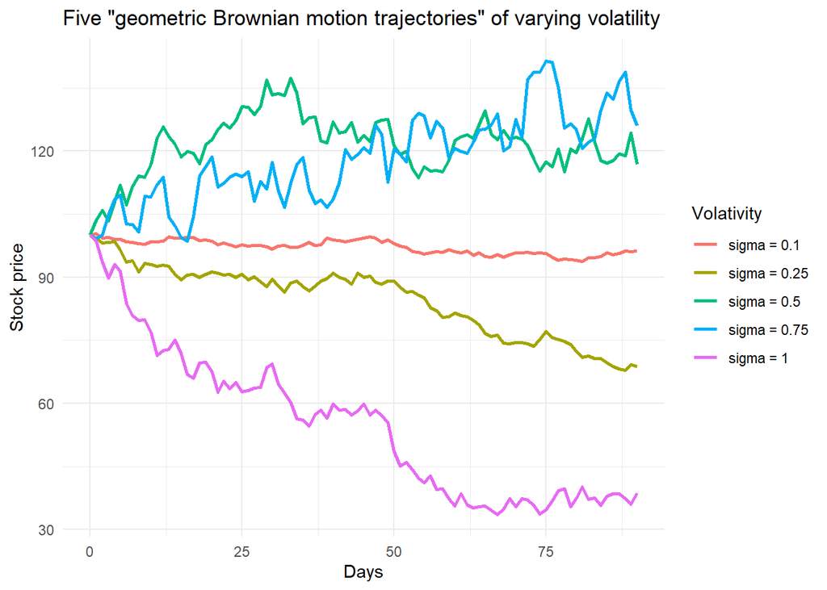

```r
Tf <- 90
S0 <- 100 # Starting stock price
mu <- 0.05 # Stock drift rate per year
dt <- 1/365
sigma <- c(0.1, 0.25, 0.5, 0.75, 1) # volatility
strike <- 105 # strike price of call option
knock_out <- 130

sim1 <- data.frame(S = GBMSim1D(Tf = Tf, dt = dt, d = 1, S0 = S0, mu = mu, sigma = sigma[1])[1:91])
sim2 <- data.frame(S = GBMSim1D(Tf = Tf, dt = dt, d = 1, S0 = S0, mu = mu, sigma = sigma[2])[1:91])
sim3 <- data.frame(S = GBMSim1D(Tf = Tf, dt = dt, d = 1, S0 = S0, mu = mu, sigma = sigma[3])[1:91])
sim4 <- data.frame(S = GBMSim1D(Tf = Tf, dt = dt, d = 1, S0 = S0, mu = mu, sigma = sigma[4])[1:91])
sim5 <- data.frame(S = GBMSim1D(Tf = Tf, dt = dt, d = 1, S0 = S0, mu = mu, sigma = sigma[5])[1:91])

df <- bind_cols(S = bind_rows(sim1, sim2, sim3, sim4, sim5), t = rep(0:90, 5), simulation = c(rep("sigma0.1", 91), rep("sigma0.25", 91), rep("sigma0.5", 91), rep("sigma0.75", 91), rep("sigma1", 91)))

df %>% ggplot(mapping = aes(x = t, y = S, colour = simulation)) + geom_line(size = 1) + labs(title = "Five \"geometric Brownian motion trajectories\" of varying volatility", x = "Days", y = "Stock price") + scale_colour_discrete(name = "Volativity", labels = c("sigma = 0.1", "sigma = 0.25", "sigma = 0.5", "sigma = 0.75", "sigma = 1"))
```

We may use these simulations to calculate payoff with the knock-out-function:

```r
KOcheck <- function(v, knock_out) {
   #Returns 1 if there has been a knockout, 0 if there has not been a knock out.
   if(sum(v>=knock_out)>0) {
      return(1)
   } else {
      return(0)
   }
}

KOPayoff <- function(Tf, dt, d, S0, mu, sigma, strike, knock_out) {
   #Calculates payout.
   S <- GBMSim1D(Tf, dt, d, S0, mu, sigma)[1:(Tf+1),]
   KOs <- apply(S, 2, KOcheck, knock_out = knock_out)
   payoff <- rep(NA, d)
   for (i in 1:d) {
      payoff[i] <- (1-KOs[i])*max(S[Tf+1,i]-strike, 0)
   }
   return(payoff)
}
```

We may calculate the payoff and the mean gain of the option.

```r
payoff <- KOPayoff(Tf = Tf, dt = dt, d = 1000, S0 = S0, mu = mu, sigma = sigma[3], strike = 105, knock_out = 130)
mean(payoff)
```

```
## [1] 1.369024
```

We may compare to the regular option

```r
ndays <- 90
S0 <- 100 # Starting stock price
mu <- 0.05 # Stock drift rate per year
dT <- 1/365
sigma <- 0.5 # volatility
strike <- 105 # strike price of call option
# Draw some normal random numbers ~ N(0,1)
niters <- 1000 # Number of Monte carlo simulations to do

option.payoff.arr <- c()

stock.prices <- list()
S90 <- c()
for (j in 1:niters) {
   N <- rnorm(ndays)
   S <- S0
   S_arr <- c(S0)
   for(i in 1:ndays) {
      dS <- S*(mu*dT + sigma*sqrt(dT)*N[i])
      S <- S + dS
      S_arr <- c(S_arr, S)
   }

   S90 <- c(S90, S)
   stock.prices[[j]] <- S_arr

   # For a call option, if the stock price at expiry is
   # higher than strike price, then we profit
   # Otherwise, we don't exercise the option
   option.payoff = max(S-strike,0)
   option.payoff.arr <- c(option.payoff.arr, option.payoff)
}
mean(option.payoff.arr)
```

```
## [1] 8.151504
```

We thus decide that the KO option is

```r
mean(option.payoff.arr) - mean(payoff)
```

```
## [1] 6.78248
```

cheaper.

We may plot the two payoffs:

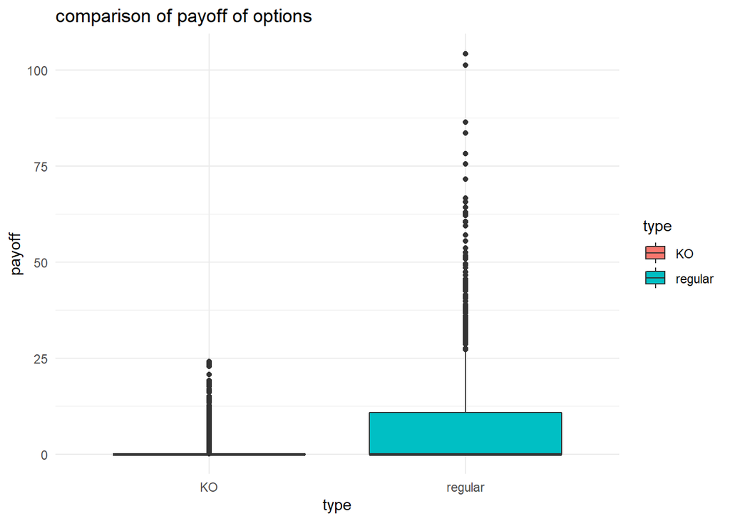

```r
d <- 1000
payoff_compare <- data.frame(payoff = bind_rows(data.frame(payoff = option.payoff.arr), data.frame(payoff = payoff)), type = c(rep("regular", d), rep("KO", d)))

payoff_compare %>% ggplot(aes(x = type, y = payoff, fill = type)) + geom_boxplot() + labs(title = "comparison of payoff of options")
```

#3